# Motivated Reasoning Regressions

Estimating the average and heterogeneous effects of judicial partisan affiliation on decisions

Apoorva Lal http://apoorvalal.github.io/ (Stanford)  
2021-07-20

```
      wants          loaded
 [1,] "tidyverse"    TRUE
 [2,] "data.table"   TRUE
 [3,] "fst"          TRUE
 [4,] "fixest"       TRUE
 [5,] "rio"          TRUE
 [6,] "glue"         TRUE
 [7,] "fastDummies"  TRUE
 [8,] "janitor"      TRUE
 [9,] "tictoc"       TRUE
[10,] "patchwork"    TRUE
[11,] "lubridate"    TRUE
[12,] "cobalt"       TRUE
[13,] "modelsummary" TRUE
[14,] "IRdisplay"    TRUE
[15,] "knitr"        TRUE
[16,] "rmarkdown"    TRUE
[17,] "kableExtra"   TRUE
[18,] "tictoc"       TRUE
[19,] "doMC"         TRUE
[20,] "grf"          TRUE
[21,] "DoubleML"     TRUE
[22,] "npcausal"     TRUE
[23,] "rlearner"     TRUE
[24,] "glmnet"       TRUE
```

```
     wants       loaded
[1,] "knitr"     TRUE
[2,] "rmarkdown" TRUE
```

# Data Prep

```
tic()
df = fread(file.path(root, "scratch/new_cases.csv")) %>% clean_names
toc()


dropcols = c('decision_date', 'termdate', 'tapeyear')
df[, (dropcols) := NULL]
# %% timestamp
df[, filing_year := year(filing_date)]
cat(glue("Missing share: {format(sum(is.na(df$filing_year))/nrow(df), 3)}"))

# %% subset on outcome
df = df[judgment %in% c(1, 2)]
df[, favors_plaintiff := ifelse(judgment == 2, 1, 0)]

# %% drop marginal parties
setnames(df, 'party_of_appointing_president', 'party')
df = df[party %in% c('Republican', 'Democratic')]
df[, rep := ifelse(party == "Republican", 1, 0)]

# %% district year FE
df[, district_year := .GRP, by =  .(district, filing_year)]
# %% number of unique values for covariates
X = c('classact', 'juris', 'origin', 'office', 'nos', 'residenc')
df[, (X) := lapply(.SD, function(x) as.factor(x)), .SDcols = X]
df[, lapply(.SD, nunique), .SDcols = X]
# %% drop rows with missing
kvs = c('favors_plaintiff', 'rep',  X, 'district_year', 'district')
df = df[, ..kvs] %>% na.omit()
# %% dummy columns
Xmat = dummy_cols(df[, ..X], select_columns = X, remove_first_dummy = TRUE,
  remove_selected_columns = TRUE)

data_main = cbind(df[, .(favors_plaintiff, rep, district, district_year)], Xmat)

fwrite(data_main, file.path(root, "scratch/prepped_data.csv"))

cat("Tabulations of categorical variables")
summary(df[, ..X])
```

## Covariate descriptions

- `classact`: Involves an allegation by the plaintiff that the complaint meets the prerequisites of a ”Class Action” as provided in Rule 23 - F.R.CV.P.
- `juris`: The code which provides the basis for the U.S. district court jurisdiction in the case. This code is used in conjunction with appropriate nature of suit code.
- `origin`: A single digit code describing the manner in which the case was filed in the district
- `office`: The code that designates the office within the district where the case is filed
- `nos`: Nature of Suit: A 3 digit statistical code representing the nature of the action filed
- `residenc`: Involves diversity of citizenship for the plaintiff and defendant. First position is the citizenship of the plaintiff, second position is the citizenship of the defendant

## Partialling out block indicators

Judges are randomly assigned within district-year, so the essentially serve as randomisation blocks. We partial them out of the treatment, outcome, and covariates before subsequent analysis.

```
partialer = function(v, fitted = F){
  # subset dataframe
  kv = c(v, 'district_year'); dat = data_main[, ..kv]
  f = formula_fixest(v, X = "1", D = "district_year")
  m = feols(f, data = dat)
  if (fitted == F){
    return(m$residuals)
  } else{
    return(m$fitted.values)
  }
}

# residualise treatment and outcome
resid_y  = partialer('favors_plaintiff')
resid_d  = partialer('rep')

# residualise covariates
tic()
Xvars = colnames(Xmat)
resid_X = map(Xvars, partialer)
toc()

# construct dataframe partialled out
resid_X = resid_X  %>% setDT
resid_df = cbind(resid_y, resid_d, resid_X, data_main$district)
setnames(resid_df, c("y", "d", c(colnames(Xmat), 'district')))
resid_df %>% glimpse

save(resid_df, data_main, file = file.path(root, "scratch/residualised_data.RData"))

# prep for Rlearner - fit nuisance functions

fitted_y  = partialer('favors_plaintiff', T)
fitted_d  = partialer('rep', T)

big_df2 = data.table(
  y = data_main[['favors_plaintiff']],
  w = data_main[['rep']],
  fitted_y,
  fitted_d,
  data_main[, ..Xvars]
)

save(big_df2, file = file.path(root, "scratch/wide_df_rlearner.RData"))
```

# Estimation

## ATE

Since we have partialled out block-FEs from the treatment and outcome, we can estimate the average treatment effect by linear regression.

```
load(file.path(root, "scratch/residualised_data.RData"))
m0 = feols(y ~ d-1, data = resid_df, cluster = ~district)
etable(m0)
```

```
                              m0
Dependent Var.:                y

d               0.0104* (0.0047)
_______________ ________________
S.E.: Clustered     by: district
Observations             821,019
R2                       0.00016
Adj. R2                  0.00016
```

## Partial Linear Regression

To account for residual confounding from covariates, we also estimate the following partial linear regression

$$\begin{aligned}
Y=& D \theta_{0}+g_{0}(X)+\zeta, & \mathbb{E}(\zeta \mid D, X) =0 \\
D=& m_{0}(X)+V, & \mathbb{E}(V \mid X) =0
\end{aligned}$$

where $X$ are covariates. We estimate $g$ and $m$ using regularized regression (LASSO) and use sample-splitting.

```
load(file.path(root, "scratch/residualised_data.RData"))
dml_data = DoubleMLData$new(resid_df,
                             y_col = "y",
                             d_cols = "d",
                             x_cols = colnames(Xmat))
dml_data
library(mlr3)
library(mlr3learners)
# surpress messages from mlr3 package during fitting
lgr::get_logger("mlr3")$set_threshold("warn")

# random forest for nuisance functions takes too long
# learner = lrn("regr.ranger", num.trees=500, max.depth=5, min.node.size=2)
# lasso
learner = lrn("regr.glmnet")
# set to use 4 CPUs
set_threads(learner, n = 4)
ml_g_bonus = learner$clone()
ml_m_bonus = learner$clone()
set.seed(94305)
dml_1 = DoubleMLPLR$new(dml_data, ml_g=ml_g_bonus, ml_m=ml_m_bonus)
dml_1$fit()
dml_1$summary()

save(dml_1, file = file.path(root, "scratch/plr1.RData"))
```

```
[1] "Estimates and significance testing of the effect of target\n                variables"
  Estimate. Std. Error t value Pr(>|t|)
d  0.009109   0.000813    11.2   <2e-16 ***
---
Signif. codes:  0 ‘***’ 0.001 ‘**’ 0.01 ‘*’ 0.05 ‘.’ 0.1 ‘ ’ 1
```

Estimates from the simple regression and regression adjustment are both on the order of 1 percentage point.

## Heterogeneous Effects

```
load(file.path(root, "scratch/residualised_data.RData"))
dt_samp = data_main[sample(1:nrow(data_main), 1e5)]

Y = dt_samp[['favors_plaintiff']]
W = dt_samp[['rep']]
district_id = dt_samp[['district']] %>% as.factor %>%  as.numeric
X = dt_samp %>% .[, 5:ncol(.)] %>% remove_constant %>% as.matrix()
dyDummies = model.matrix(~ -1 + as.factor(district_year), dt_samp)
```

### causal forest

```
# residualise on district X year FEs
Y.forest = regression_forest(dyDummies, Y, clusters = district_id)
W.forest = regression_forest(dyDummies, W, clusters = district_id)
Y.hat = predict(Y.forest)$predictions
W.hat = predict(W.forest)$predictions

# causal forest takes orthogonalized fitted values
cf0 = causal_forest(X, Y, W,
                       Y.hat = Y.hat, W.hat = W.hat,
                       clusters = district_id)

# causal forest takes orthogonalized fitted values
cf_raw = causal_forest(X, Y, W,
                       Y.hat = Y.hat, W.hat = W.hat,
                       clusters = district_id)
varimp = variable_importance(cf_raw)
selected= which(varimp > mean(varimp))

# causal forest takes orthogonalized fitted values
cf0 = causal_forest(X[, selected], Y, W,
                       Y.hat = Y.hat, W.hat = W.hat,
                       clusters = district_id)

save(cf0, file = file.path(root, "scratch/causal_forest_fit.rdata"))
```

```
load(file.path(root, "scratch/causal_forest_fit.rdata"))
```

```
average_treatment_effect(cf0)
```

```
estimate  std.err
0.013467 0.006559
```

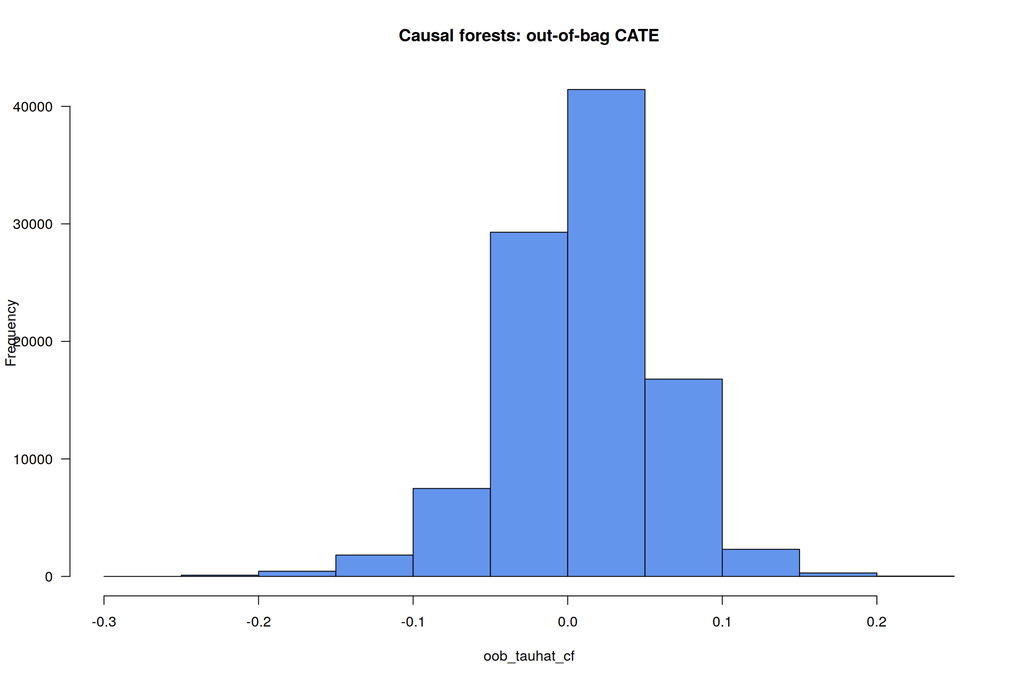

```
oob_pred <- predict(cf0)
oob_tauhat_cf <- oob_pred$predictions
hist(oob_tauhat_cf, main="Causal forests: out-of-bag CATE",
  col = "cornflowerblue", las = 1)
```

#### omnibus test

```
tic()
tc <- test_calibration(cf0)
toc()
save(tc, file = file.path(root, "scratch/omnibus.RData"))
```

```
load(file.path(root, "scratch/omnibus.RData"))
caption <- "Best linear fit using forest predictions (on held-out data)
                      as well as the mean forest prediction as regressors, along
                      with heteroskedasticity-robust (HC3) SEs."
table <- as.data.frame(tc[,])
table %>%
    kable(format="html", digits=6, caption=caption, escape = FALSE, row.names = FALSE) %>%
    kable_styling(bootstrap_options=c("condensed", "responsive"), full_width=FALSE)
```

Table 1: Best linear fit using forest predictions (on held-out data) as well as the mean forest prediction as regressors, along with heteroskedasticity-robust (HC3) SEs.

| Estimate | Std. Error | t value | Pr(>t) |
| --- | --- | --- | --- |
| 1.5710 | 0.7657 | 2.0518 | 0.02009 |
| -0.1014 | 0.1668 | -0.6075 | 0.72825 |

#### Variable importance in causal forest

```
var_imp <- c(variable_importance(cf0))
names(var_imp) <- colnames(cf0$X.orig)
sorted_var_imp <- sort(var_imp, decreasing=TRUE)
as.data.frame(sorted_var_imp, row.names = names(sorted_var_imp)) %>%
  slice(1:10) %>%
  kable("html", digits = 4, row.names = T) %>%
  kable_styling(bootstrap_options=c("striped", "hover", "condensed", "responsive"), full_width=FALSE)
```

|  | sorted_var_imp |
| --- | --- |
| office_3 | 0.1504 |
| nos_550 | 0.1248 |
| classact_0 | 0.0986 |
| office_1 | 0.0653 |
| juris_2 | 0.0610 |
| office_4 | 0.0595 |
| office_5 | 0.0583 |
| nos_890 | 0.0522 |
| office_2 | 0.0484 |
| juris_3 | 0.0400 |

#### Best Linear Predictor of CATEs

```
best_linear_projection(cf0, cf0$X.orig)
```

```
Best linear projection of the conditional average treatment effect.
Confidence intervals are cluster- and heteroskedasticity-robust (HC3):

            Estimate Std. Error t value Pr(>|t|)
(Intercept)  0.17078    0.06138    2.78  0.00540 **
classact_0   0.03239    0.01725    1.88  0.06046 .
juris_2     -0.01734    0.05637   -0.31  0.75832
juris_3     -0.02114    0.04420   -0.48  0.63243
juris_4     -0.06212    0.04724   -1.31  0.18854
origin_1    -0.07561    0.02279   -3.32  0.00091 ***
origin_2    -0.06873    0.02715   -2.53  0.01137 *
origin_4    -0.07497    0.03081   -2.43  0.01498 *
office_1    -0.04965    0.03846   -1.29  0.19679
office_2    -0.05669    0.03915   -1.45  0.14757
office_3    -0.08925    0.04225   -2.11  0.03467 *
office_4    -0.06871    0.07099   -0.97  0.33312
office_5    -0.02321    0.06271   -0.37  0.71130
office_6     0.02156    0.04913    0.44  0.66075
nos_190     -0.00829    0.02542   -0.33  0.74440
nos_440      0.01164    0.02269    0.51  0.60803
nos_442     -0.01013    0.03205   -0.32  0.75200
nos_530     -0.02401    0.02394   -1.00  0.31587
nos_550     -0.05305    0.03112   -1.70  0.08830 .
nos_863     -0.04304    0.05324   -0.81  0.41886
nos_864     -0.01691    0.03793   -0.45  0.65563
nos_890     -0.04884    0.02894   -1.69  0.09147 .
residenc_15  0.05132    0.04197    1.22  0.22151
---
Signif. codes:  0 '***' 0.001 '**' 0.01 '*' 0.05 '.' 0.1 ' ' 1
```

### R-Learner

Nie-Wager (2020).

We first fit nuisance functions ($\wh{m}, \wh{e}$) with fixed-effects with cross-fitting. We then use these as inputs into the problem of learning

$$\hat{\tau}(\cdot) = \argmin_\tau \Bigpar{\wh{L}_n{\tau(\cdot)} + \Lambda_n{\tau(\cdot)} }$$

where
$$\wh{L}\Bigpar{\tau(\cdot)} = \frac{1}{n} \sumiN \Bigpar{
\Bigpar{Y_i - \wh{m}^{-q(i)} (X_i) } -
\Bigpar{W_i - \wh{e}^{-q(i)} (X_i)}
}^2$$

where the second piece is called R-loss (after Robinson regression).

```
load(file.path(root, "scratch/wide_df_rlearner.RData"))
df2 = big_df2 #[sample(.N, 1e5)]
y    = df2[['y']]
mhat = df2[['fitted_y']]
w    = df2[['w']]
what = df2[['fitted_d']]
X = df2[, 5:ncol(df2)] %>% remove_constant() %>% as.matrix()
```

```
tic()
tau_lasso = rlasso(X, w, y, p_hat = what, m_hat = mhat)
toc()

tic()
tau_lasso2 = rlasso(X, w, y, p_hat = what, m_hat = mhat, rs = T)
toc()

save(tau_lasso, tau_lasso2, file = file.path(root, "scratch/rlasso_fit.RData"))
```

```
load(file.path(root, "scratch/rlasso_fit.RData"))
# fit_df = data.frame(tau1 = predict(tau_lasso, X),  tau2 = predict(tau_lasso2, X))
cat("ATE:", mean(tau_lasso$tau_hat))
```

```
ATE: 0.01115
```

```
cat("ATE:", mean(tau_lasso2$tau_hat))
```

```
ATE: 0.01115
```

```
coefs = data.table(var = c("intercept", colnames(X)), est1 = round(tau_lasso$tau_beta, 3),
  est2 = round(tau_lasso2$tau_beta, 3))

coefs[order(-abs(est1))][est1>0]
```

```
            var  est1  est2
 1:   intercept 0.011 0.011
 2:     nos_196 0.011 0.011
 3:    office_A 0.008 0.008
 4:     nos_444 0.007 0.007
 5: residenc_62 0.007 0.007
 6:     juris_5 0.006 0.006
 7:     nos_345 0.006 0.006
 8:     nos_355 0.006 0.006
 9:     nos_380 0.006 0.006
10:     nos_660 0.006 0.006
11:     nos_860 0.006 0.006
12:     nos_896 0.006 0.006
13: residenc_46 0.006 0.006
14: residenc_53 0.006 0.006
```

[output cut: 48 more lines]

[NOS reference](https://pacer.uscourts.gov/sites/default/files/files/nature%20of%20suit%20codes.pdf)

- `nos_196`: Franchise Action
- `nos_444`: Welfare
- `residenc_62`: suits involving immigrants?